# Исследование поиска закономерностей успешности продаж компьютерных игр

## Описание проекта

Вы работаете в интернет-магазине «Стримчик», который продаёт по всему миру компьютерные игры. Из открытых источников доступны исторические данные о продажах игр, оценки пользователей и экспертов, жанры и платформы (например, Xbox или PlayStation). Вам нужно выявить определяющие успешность игры закономерности. Это позволит сделать ставку на потенциально популярный продукт и спланировать рекламные кампании.

### Описание данных

Перед вами данные до 2016 года. Представим, что сейчас декабрь 2016 г., и вы планируете кампанию на 2017-й. Нужно отработать принцип работы с данными. Неважно, прогнозируете ли вы продажи на 2017 год по данным 2016-го или же 2027-й — по данным 2026 года.

В наборе данных попадается аббревиатура ESRB (Entertainment Software Rating Board) — это ассоциация, определяющая возрастной рейтинг компьютерных игр. ESRB оценивает игровой контент и присваивает ему подходящую возрастную категорию, например, «Для взрослых», «Для детей младшего возраста» или «Для подростков».

### План работы

Проанализируем предоставленные данные. Проведём ииследования полученных данных с их визуализацией. Проверим ряд гипотез и опишем полученные выводы.

Таким образом, исследование пройдёт в 6 этапов:  
Загрузка и обзор данных  
Предобработка данных  
Исследовательский анализ данных  
Составим портрет пользователя каждого региона  
Проверка гипотез  
Общий вывод

## Шаг 1. Откроем файл с данными и изучим общую информацию.

```python
import pandas as pd
import numpy as np
import matplotlib.pyplot as plt
import seaborn as sns
from scipy.stats import binom, norm
from scipy import stats as st
import random
from math import sqrt
pd.set_option('chained_assignment', None)
```

```python
%%javascript
IPython.OutputArea.auto_scroll_threshold = 9999;
```

```python
players = pd.read_csv('/datasets/games.csv')
players.head(10)
```

|  | Name | Platform | Year_of_Release | Genre | NA_sales | EU_sales | JP_sales | Other_sales | Critic_Score | User_Score | Rating |
| --- | --- | --- | --- | --- | --- | --- | --- | --- | --- | --- | --- |
| 0 | Wii Sports | Wii | 2006.0 | Sports | 41.36 | 28.96 | 3.77 | 8.45 | 76.0 | 8 | E |
| 1 | Super Mario Bros. | NES | 1985.0 | Platform | 29.08 | 3.58 | 6.81 | 0.77 | NaN | NaN | NaN |
| 2 | Mario Kart Wii | Wii | 2008.0 | Racing | 15.68 | 12.76 | 3.79 | 3.29 | 82.0 | 8.3 | E |
| 3 | Wii Sports Resort | Wii | 2009.0 | Sports | 15.61 | 10.93 | 3.28 | 2.95 | 80.0 | 8 | E |
| 4 | Pokemon Red/Pokemon Blue | GB | 1996.0 | Role-Playing | 11.27 | 8.89 | 10.22 | 1.00 | NaN | NaN | NaN |
| 5 | Tetris | GB | 1989.0 | Puzzle | 23.20 | 2.26 | 4.22 | 0.58 | NaN | NaN | NaN |
| 6 | New Super Mario Bros. | DS | 2006.0 | Platform | 11.28 | 9.14 | 6.50 | 2.88 | 89.0 | 8.5 | E |
| 7 | Wii Play | Wii | 2006.0 | Misc | 13.96 | 9.18 | 2.93 | 2.84 | 58.0 | 6.6 | E |
| 8 | New Super Mario Bros. Wii | Wii | 2009.0 | Platform | 14.44 | 6.94 | 4.70 | 2.24 | 87.0 | 8.4 | E |
| 9 | Duck Hunt | NES | 1984.0 | Shooter | 26.93 | 0.63 | 0.28 | 0.47 | NaN | NaN | NaN |

```python
players.columns
```

```
Index(['Name', 'Platform', 'Year_of_Release', 'Genre', 'NA_sales', 'EU_sales',
       'JP_sales', 'Other_sales', 'Critic_Score', 'User_Score', 'Rating'],
      dtype='object')
```

*Наблюдаем не корректность в названиях столбцов. Приведём названия в соответствие с хорошим стилем. Наблюдаем не корректность типов данных в столбце "User_Score"с типом object или в годе выпуска "Year_of_Release" с типом float. Также нужно проверить данные на наличие дубликатов, по возможности, заполнить пропуски и сгруппировать данные для наглядности.*

## Шаг 2. Проведём предобработку данных

```python
players.columns = players.columns.str.lower()
players.columns
```

```
Index(['name', 'platform', 'year_of_release', 'genre', 'na_sales', 'eu_sales',
       'jp_sales', 'other_sales', 'critic_score', 'user_score', 'rating'],
      dtype='object')
```

```python
players.head(10)
```

|  | name | platform | year_of_release | genre | na_sales | eu_sales | jp_sales | other_sales | critic_score | user_score | rating |
| --- | --- | --- | --- | --- | --- | --- | --- | --- | --- | --- | --- |
| 0 | Wii Sports | Wii | 2006.0 | Sports | 41.36 | 28.96 | 3.77 | 8.45 | 76.0 | 8 | E |
| 1 | Super Mario Bros. | NES | 1985.0 | Platform | 29.08 | 3.58 | 6.81 | 0.77 | NaN | NaN | NaN |
| 2 | Mario Kart Wii | Wii | 2008.0 | Racing | 15.68 | 12.76 | 3.79 | 3.29 | 82.0 | 8.3 | E |
| 3 | Wii Sports Resort | Wii | 2009.0 | Sports | 15.61 | 10.93 | 3.28 | 2.95 | 80.0 | 8 | E |
| 4 | Pokemon Red/Pokemon Blue | GB | 1996.0 | Role-Playing | 11.27 | 8.89 | 10.22 | 1.00 | NaN | NaN | NaN |
| 5 | Tetris | GB | 1989.0 | Puzzle | 23.20 | 2.26 | 4.22 | 0.58 | NaN | NaN | NaN |
| 6 | New Super Mario Bros. | DS | 2006.0 | Platform | 11.28 | 9.14 | 6.50 | 2.88 | 89.0 | 8.5 | E |
| 7 | Wii Play | Wii | 2006.0 | Misc | 13.96 | 9.18 | 2.93 | 2.84 | 58.0 | 6.6 | E |
| 8 | New Super Mario Bros. Wii | Wii | 2009.0 | Platform | 14.44 | 6.94 | 4.70 | 2.24 | 87.0 | 8.4 | E |
| 9 | Duck Hunt | NES | 1984.0 | Shooter | 26.93 | 0.63 | 0.28 | 0.47 | NaN | NaN | NaN |

*Описание данных:*

- name — название игры
- platform — платформа
- year_of_release — год выпуска
- genre — жанр игры
- na_sales — продажи в Северной Америке (миллионы проданных копий)
- eu_sales — продажи в Европе (миллионы проданных копий)
- jp_sales — продажи в Японии (миллионы проданных копий)
- other_sales — продажи в других странах (миллионы проданных копий)
- critic_score — оценка критиков (максимум 100)
- user_score — оценка пользователей (максимум 10)
- rating — рейтинг от организации ESRB (англ. Entertainment Software Rating Board). Эта ассоциация определяет рейтинг компьютерных игр и присваивает им подходящую возрастную категорию.

```python
players.info()
```

```
<class 'pandas.core.frame.DataFrame'>
RangeIndex: 16715 entries, 0 to 16714
Data columns (total 11 columns):
 #   Column           Non-Null Count  Dtype
---  ------           --------------  -----
 0   name             16713 non-null  object
 1   platform         16715 non-null  object
 2   year_of_release  16446 non-null  float64
 3   genre            16713 non-null  object
 4   na_sales         16715 non-null  float64
 5   eu_sales         16715 non-null  float64
 6   jp_sales         16715 non-null  float64
 7   other_sales      16715 non-null  float64
 8   critic_score     8137 non-null   float64
 9   user_score       10014 non-null  object
 10  rating           9949 non-null   object
dtypes: float64(6), object(5)
memory usage: 1.4+ MB
```

```python
players.isna().sum()
```

```
name                  2
platform              0
year_of_release     269
genre                 2
na_sales              0
eu_sales              0
jp_sales              0
other_sales           0
critic_score       8578
user_score         6701
rating             6766
dtype: int64
```

```python
players.query('name != name') # вывод строк с пропусками в столбце "name"
```

|  | name | platform | year_of_release | genre | na_sales | eu_sales | jp_sales | other_sales | critic_score | user_score | rating |
| --- | --- | --- | --- | --- | --- | --- | --- | --- | --- | --- | --- |
| 659 | NaN | GEN | 1993.0 | NaN | 1.78 | 0.53 | 0.00 | 0.08 | NaN | NaN | NaN |
| 14244 | NaN | GEN | 1993.0 | NaN | 0.00 | 0.00 | 0.03 | 0.00 | NaN | NaN | NaN |

*2 строки с пропущенными именами имеют значительное количество пропусков и целесообразно их удалить. В них также присутствуют 2 имеющихся пропуска в столбце 'genre'.*

```python
players = players.query('name == name')
players.isna().sum()
```

```
name                  0
platform              0
year_of_release     269
genre                 0
na_sales              0
eu_sales              0
jp_sales              0
other_sales           0
critic_score       8576
user_score         6699
rating             6764
dtype: int64
```

*Изучим данные в столбце года выпуска (year_of_release) и оценим количество пропусков.*

```python
print('Количество пропусков в столбце года выпуска:',
      players['year_of_release'].isna().sum())
print('Доля пропусков в столбце года выпуска:',
      players['year_of_release'].isna().sum()/len(players['year_of_release'])*100,'%')
```

```
Количество пропусков в столбце года выпуска: 269
Доля пропусков в столбце года выпуска: 1.6095255190570215 %
```

*Доля пропусков в столбце года выпуска составляет 1.6%. Удаляем эти строки и меняем тип данных на целочисленный.*

```python
players = players.dropna(subset=['year_of_release'])
players['year_of_release'] = players['year_of_release'].astype('int')
players['year_of_release'].unique()
```

```
array([2006, 1985, 2008, 2009, 1996, 1989, 1984, 2005, 1999, 2007, 2010,
       2013, 2004, 1990, 1988, 2002, 2001, 2011, 1998, 2015, 2012, 2014,
       1992, 1997, 1993, 1994, 1982, 2016, 2003, 1986, 2000, 1995, 1991,
       1981, 1987, 1980, 1983])
```

```python
print('Данные предоставлены с', players['year_of_release'].min(), 'по', players['year_of_release'].max(), 'год')
```

```
Данные предоставлены с 1980 по 2016 год
```

```python
players['critic_score'].unique()
```

```
array([76., nan, 82., 80., 89., 58., 87., 91., 61., 97., 95., 77., 88.,
       83., 94., 93., 85., 86., 98., 96., 90., 84., 73., 74., 78., 92.,
       71., 72., 68., 62., 49., 67., 81., 66., 56., 79., 70., 59., 64.,
       75., 60., 63., 69., 50., 25., 42., 44., 55., 48., 57., 29., 47.,
       65., 54., 20., 53., 37., 38., 33., 52., 30., 32., 43., 45., 51.,
       40., 46., 39., 34., 41., 36., 31., 27., 35., 26., 19., 28., 23.,
       24., 21., 17., 13.])
```

```python
players['user_score'].unique()
```

```
array(['8', nan, '8.3', '8.5', '6.6', '8.4', '8.6', '7.7', '6.3', '7.4',
       '8.2', '9', '7.9', '8.1', '8.7', '7.1', '3.4', '5.3', '4.8', '3.2',
       '8.9', '6.4', '7.8', '7.5', '2.6', '7.2', '9.2', '7', '7.3', '4.3',
       '7.6', '5.7', '5', '9.1', '6.5', 'tbd', '8.8', '6.9', '9.4', '6.8',
       '6.1', '6.7', '5.4', '4', '4.9', '4.5', '9.3', '6.2', '4.2', '6',
       '3.7', '4.1', '5.8', '5.6', '5.5', '4.4', '4.6', '5.9', '3.9',
       '3.1', '2.9', '5.2', '3.3', '4.7', '5.1', '3.5', '2.5', '1.9', '3',
       '2.7', '2.2', '2', '9.5', '2.1', '3.6', '2.8', '1.8', '3.8', '0',
       '1.6', '9.6', '2.4', '1.7', '1.1', '0.3', '1.5', '0.7', '1.2',
       '2.3', '0.5', '1.3', '0.2', '0.6', '1.4', '0.9', '1', '9.7'],
      dtype=object)
```

*В столбце оценка пользователей 'user_score' наблюдаем значение 'tbd'. Выясним природу появления таких данных.*

```python
players.loc[players['user_score'] == 'tbd'].head(10)
```

|  | name | platform | year_of_release | genre | na_sales | eu_sales | jp_sales | other_sales | critic_score | user_score | rating |
| --- | --- | --- | --- | --- | --- | --- | --- | --- | --- | --- | --- |
| 119 | Zumba Fitness | Wii | 2010 | Sports | 3.45 | 2.59 | 0.00 | 0.66 | NaN | tbd | E |
| 301 | Namco Museum: 50th Anniversary | PS2 | 2005 | Misc | 2.08 | 1.35 | 0.00 | 0.54 | 61.0 | tbd | E10+ |
| 520 | Zumba Fitness 2 | Wii | 2011 | Sports | 1.51 | 1.03 | 0.00 | 0.27 | NaN | tbd | T |
| 645 | uDraw Studio | Wii | 2010 | Misc | 1.65 | 0.57 | 0.00 | 0.20 | 71.0 | tbd | E |
| 718 | Just Dance Kids | Wii | 2010 | Misc | 1.52 | 0.54 | 0.00 | 0.18 | NaN | tbd | E |
| 726 | Dance Dance Revolution X2 | PS2 | 2009 | Simulation | 1.09 | 0.85 | 0.00 | 0.28 | NaN | tbd | E10+ |
| 821 | The Incredibles | GBA | 2004 | Action | 1.15 | 0.77 | 0.04 | 0.10 | 55.0 | tbd | E |
| 881 | Who wants to be a millionaire | PC | 1999 | Misc | 1.94 | 0.00 | 0.00 | 0.00 | NaN | tbd | E |
| 1047 | Tetris Worlds | GBA | 2001 | Puzzle | 1.25 | 0.39 | 0.00 | 0.06 | 65.0 | tbd | E |
| 1048 | Imagine: Teacher | DS | 2008 | Simulation | 0.70 | 0.82 | 0.00 | 0.19 | NaN | tbd | E |

*В общем, как говорят в Америке, TBD (to be determined = будет определено).* https://context.reverso.net/%D0%BF%D0%B5%D1%80%D0%B5%D0%B2%D0%BE%D0%B4/%D0%B0%D0%BD%D0%B3%D0%BB%D0%B8%D0%B9%D1%81%D0%BA%D0%B8%D0%B9-%D1%80%D1%83%D1%81%D1%81%D0%BA%D0%B8%D0%B9/TBD

*TBD в данном случае означает, что данные не определены и мы их можем обозначить, как пропуски. Заменим значение 'tbd' на пропуски и в дальнейшем обработаем их как пропуски. Приведём столбец к типу float.*

```python
players.user_score.replace('tbd', np.nan, inplace=True)
players['user_score'] = players['user_score'].astype('float')
```

```python
players.isna().sum()
```

```
name                  0
platform              0
year_of_release       0
genre                 0
na_sales              0
eu_sales              0
jp_sales              0
other_sales           0
critic_score       8461
user_score         8981
rating             6676
dtype: int64
```

```python
players['rating'].unique()
```

```
array(['E', nan, 'M', 'T', 'E10+', 'K-A', 'AO', 'EC', 'RP'], dtype=object)
```

*Рейтинг игр ESRB:*

*«EC» («Early childhood») — «Для детей младшего возраста»:*\ Игра подходит для детей от 3 лет и не содержит материалов, которые родители могли бы счесть неподходящими. Продукты, получившие данный рейтинг, изначально разрабатываются для детей и обычно представляют собой развивающие игры.

*«E» («Everyone») — «Для всех»:*\ Содержание вполне подходит для всех возрастов (ранее с 6 лет). Такие игры могут понравиться и взрослым. Игры с этим рейтингом могут содержать минимальное насилие, в основном «мультяшного» характера. Первоначально "K-A" ("Kids to Adults"):

*«E10+» («Everyone 10 and older») — «Для всех от 10 лет и старше»:*\  
Проекты с данным рейтингом могут содержать больше мультипликационного или мягкого насилия, или несколько откровенные сцены, или минимальное количество крови. Рейтинг был принят ESRB 2 марта 2005 года.

*«T» («Teen») — «Подросткам»:*  
Игра подходит для лиц от 13 лет. Проекты из данной категории могут содержать насилие, непристойные сцены, грубый юмор, в меру откровенное сексуальное содержимое, кровь или нечастое использование ненормативной лексики.

*«M» («Mature») — «Для взрослых»:*  
Материалы игры не подходят для лиц младше 17 лет. Проекты с данным рейтингом могут содержать жестокое насилие, большое количество крови с расчленением, непристойные сексуальные сцены или грубую ненормативную лексику.

*«AO» («Adults Only 18+») — «Только для взрослых»:*  
Содержание игры только для взрослых старше 18 лет. Продукты из данной категории могут содержать длительные сцены жестокого насилия и/или очень откровенное сексуальное содержимое.

*«RP» («Rating Pending») — «Рейтинг ожидается»:*  
Продукт был отправлен в ESRB и ожидает присвоения рейтинга. Данный логотип используется только на рекламных презентациях и в демо-версиях игр до официальной даты выпуска в продажу:

*«RP 17+» («Rating Pending») — «Рейтинг ожидается - примерно 17+»:* Продукт отправлен ESRB на оценку, но примерное содержание близко к рейтингу «M». Данная маркировка была введена с 2021 г. и распространяется на демо или презентационный вариант.

https://ru.wikipedia.org/wiki/Entertainment_Software_Rating_Board#:~:text=Entertainment%20Software%20Rating%20Board%20(ESRB,%D0%BE%D0%B1%D0%B5%D1%81%D0%BF%D0%B5%D1%87%D0%B5%D0%BD%D0%B8%D1%8F%20%D0%B2%20%D0%A1%D0%A8%D0%90%20%D0%B8%20%D0%9A%D0%B0%D0%BD%D0%B0%D0%B4%D0%B5.

*Оценим долю в пропусках столбцов*

- critic_score — оценка критиков (максимум 100)
- user_score — оценка пользователей (максимум 10)
- rating — рейтинг от организации ESRB

```python
print('Количество пропусков в столбце оценка критиков:',
      players['critic_score'].isna().sum())
print('Доля пропусков в столбце оценка критиков:',
      round(players['critic_score'].isna().sum()/len(players['critic_score'])*100, 2),'%')
```

```
Количество пропусков в столбце оценка критиков: 8461
Доля пропусков в столбце оценка критиков: 51.45 %
```

```python
print('Количество пропусков в столбце оценка пользователей:',
      players['user_score'].isna().sum())
print('Доля пропусков в столбце оценка пользователей:',
      round(players['user_score'].isna().sum()/len(players['critic_score'])*100, 2),'%')
```

```
Количество пропусков в столбце оценка пользователей: 8981
Доля пропусков в столбце оценка пользователей: 54.62 %
```

```python
print('Количество пропусков в столбце рейтинг от организации ESRB:',
      players['rating'].isna().sum())
print('Доля пропусков в столбце рейтинг от организации ESRB:',
      round(players['rating'].isna().sum()/len(players['critic_score'])*100, 2),'%')
```

```
Количество пропусков в столбце рейтинг от организации ESRB: 6676
Доля пропусков в столбце рейтинг от организации ESRB: 40.6 %
```

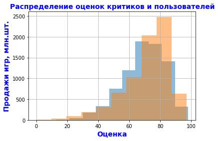

```python
fig, ax = plt.subplots()
players.critic_score.hist(ax=ax, label='Оценка критиков', alpha=0.5)
(players.user_score*10).hist(ax=ax, label='Оценка пользователей', alpha=0.5)
ax.set_xlabel('Оценка', fontsize=14, fontweight="bold", color='blue')
ax.set_ylabel('Продажи игр, млн.шт.', fontsize=14, fontweight="bold", color='blue')
ax.set_title('Распределение оценок критиков и пользователей', fontsize=14, fontweight="bold", color='blue')
plt.alpha=0.5
plt.show()
```

*Оценки критиков и пользователей достаточно близки друг к другу.*

*Рассмотрим количество игр с рейтингами и оценками в зависимости от года.*

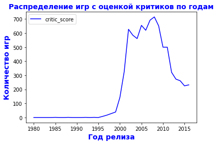

```python
players.groupby('year_of_release')['critic_score'].count().reset_index().plot(x='year_of_release', color='blue')
plt.xlabel('Год релиза', fontsize=14, fontweight="bold", color='blue')
plt.ylabel('Количество игр', fontsize=14, fontweight="bold", color='blue')
plt.title('Распределение игр с оценкой критиков по годам', fontsize=14, fontweight="bold", color='blue')
plt.show()
```

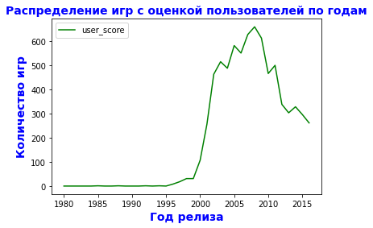

```python
players.groupby('year_of_release')['user_score'].count().reset_index().plot(x='year_of_release', color='green')
plt.xlabel('Год релиза', fontsize=14, fontweight="bold", color='blue')
plt.ylabel('Количество игр', fontsize=14, fontweight="bold", color='blue')
plt.title('Распределение игр с оценкой пользователей по годам', fontsize=14, fontweight="bold", color='blue')
plt.show()
```

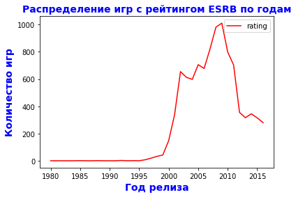

```python
players.groupby('year_of_release')['rating'].count().reset_index().plot(x='year_of_release', color='red')
plt.xlabel('Год релиза', fontsize=14, fontweight="bold", color='blue')
plt.ylabel('Количество игр', fontsize=14, fontweight="bold", color='blue')
plt.title('Распределение игр с рейтингом ESRB по годам', fontsize=14, fontweight="bold", color='blue')
plt.show()
```

*Доля пропусков в значениях оценки критиков, оценки пользователей и рейтинге от организации ESRB составляет 51.45%, 54.62% и 40.6% соответственно. Отметим, что количество игр, которым был присвоены оценки и рейтинг увеличиваются после 1995 года. Это подтверждается и датой начала присваивания оценок и рейтингов организацией Entertainment Software Rating Board (ESRB). Пропуски в значениях рейтинга заменим значением "absent".*

```python
players['rating'] = players['rating'].fillna('absent')
```

Entertainment Software Rating Board (ESRB) — негосударственная организация, основное направление деятельности — принятие и определение рейтингов для компьютерных видеоигр и другого развлекательного программного обеспечения в США и Канаде. ESRB была основана в 1994 году ассоциацией Interactive Digital Software Association (современное название — «Entertainment Software Association»). К началу 2003 года рейтинги ESRB получили более 8000 продуктов от 350 издателей. https://ru.wikipedia.org/wiki/Entertainment_Software_Rating_Board#:~:text=Entertainment%20Software%20Rating%20Board%20

*Проверим на наличие дубликатов по 3 столбцам.*

```python
display(players.loc[players.duplicated(subset=['name', 'platform', 'year_of_release'], keep=False)])
```

|  | name | platform | year_of_release | genre | na_sales | eu_sales | jp_sales | other_sales | critic_score | user_score | rating |
| --- | --- | --- | --- | --- | --- | --- | --- | --- | --- | --- | --- |
| 604 | Madden NFL 13 | PS3 | 2012 | Sports | 2.11 | 0.22 | 0.0 | 0.23 | 83.0 | 5.5 | E |
| 16230 | Madden NFL 13 | PS3 | 2012 | Sports | 0.00 | 0.01 | 0.0 | 0.00 | 83.0 | 5.5 | E |

*Значительного количества дубликатов нет. Мы их не считаем за дубликаты и оставляем.*

*Создадим новый столбец (sum_sales) с суммарными продажами по всем регионам и добавим к нашей таблице.*

```python
players['sum_sales'] = players['na_sales'] + players['eu_sales'] + players['jp_sales'] + players['other_sales']
players.head()
```

|  | name | platform | year_of_release | genre | na_sales | eu_sales | jp_sales | other_sales | critic_score | user_score | rating | sum_sales |
| --- | --- | --- | --- | --- | --- | --- | --- | --- | --- | --- | --- | --- |
| 0 | Wii Sports | Wii | 2006 | Sports | 41.36 | 28.96 | 3.77 | 8.45 | 76.0 | 8.0 | E | 82.54 |
| 1 | Super Mario Bros. | NES | 1985 | Platform | 29.08 | 3.58 | 6.81 | 0.77 | NaN | NaN | absent | 40.24 |
| 2 | Mario Kart Wii | Wii | 2008 | Racing | 15.68 | 12.76 | 3.79 | 3.29 | 82.0 | 8.3 | E | 35.52 |
| 3 | Wii Sports Resort | Wii | 2009 | Sports | 15.61 | 10.93 | 3.28 | 2.95 | 80.0 | 8.0 | E | 32.77 |
| 4 | Pokemon Red/Pokemon Blue | GB | 1996 | Role-Playing | 11.27 | 8.89 | 10.22 | 1.00 | NaN | NaN | absent | 31.38 |

```python
players[['na_sales', 'eu_sales', 'jp_sales', 'other_sales', 'sum_sales']].describe()
```

|  | na_sales | eu_sales | jp_sales | other_sales | sum_sales |
| --- | --- | --- | --- | --- | --- |
| count | 16444.000000 | 16444.000000 | 16444.000000 | 16444.000000 | 16444.000000 |
| mean | 0.264012 | 0.145930 | 0.078487 | 0.047594 | 0.536023 |
| std | 0.818378 | 0.506716 | 0.311100 | 0.188005 | 1.558786 |
| min | 0.000000 | 0.000000 | 0.000000 | 0.000000 | 0.000000 |
| 25% | 0.000000 | 0.000000 | 0.000000 | 0.000000 | 0.060000 |
| 50% | 0.080000 | 0.020000 | 0.000000 | 0.010000 | 0.170000 |
| 75% | 0.240000 | 0.110000 | 0.040000 | 0.030000 | 0.470000 |
| max | 41.360000 | 28.960000 | 10.220000 | 10.570000 | 82.540000 |

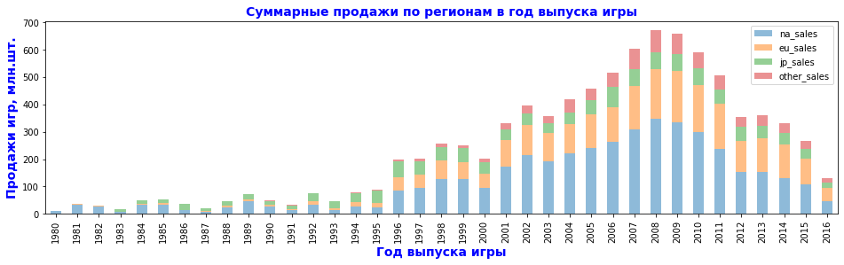

```python
fig, ax = plt.subplots()

(players.groupby('year_of_release')[['na_sales', 'eu_sales', 'jp_sales', 'other_sales']]
 .agg('sum').plot(kind='bar', stacked=True, ax=ax, figsize=(16,4), alpha=0.5))

ax.set_title('Суммарные продажи по регионам в год выпуска игры', fontsize=14, fontweight="bold", color='blue')
ax.set_ylabel('Продажи игр, млн.шт.', fontsize=14, fontweight="bold", color='blue')
ax.set_xlabel('Год выпуска игры', fontsize=14, fontweight="bold", color='blue')
plt.show()
```

*Заметно значительное преобладание объема продаж игр на рынке Северной Америке. Следом идут продажи на рынке Европы. Объём продаж в Японии и в остальных странах примерно сопоставимы.*

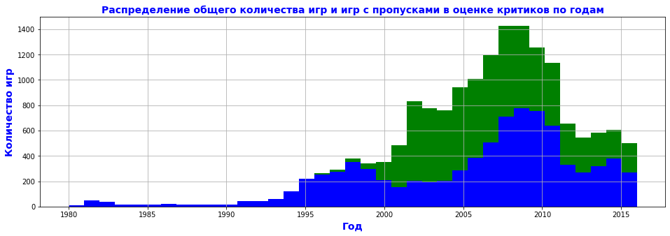

```python
critic_nan = players.query('critic_score != critic_score')

ax = players['year_of_release'].plot(kind='hist', grid=True, bins= 37, color='green', figsize=(16,5))
ax = critic_nan['year_of_release'].plot(kind='hist', bins= 37, grid=True, color='blue', figsize=(16,5))
ax.set_xlabel('Год', fontsize=14, fontweight="bold", color='blue')
ax.set_ylabel('Количество игр', fontsize=14, fontweight="bold", color='blue')
ax.set_title('Распределение общего количества игр и игр с пропусками в оценке критиков по годам',
             fontsize=14, fontweight="bold", color='blue')
None
```

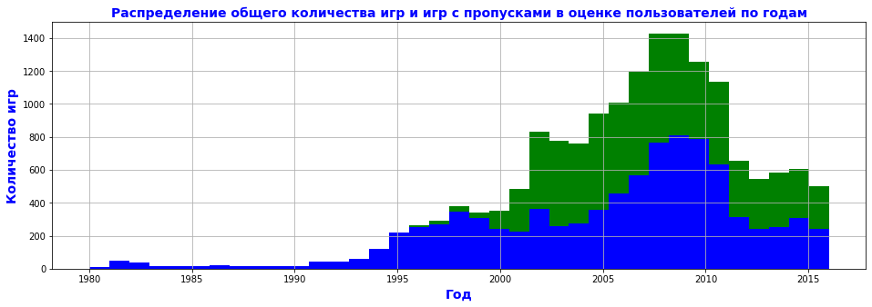

```python
user_nan = players.query('user_score != user_score')

ax = players['year_of_release'].plot(kind='hist', bins= 37, grid=True, color='green', figsize=(16,5))
ax = user_nan['year_of_release'].plot(kind='hist', bins= 37, grid=True, color='blue', figsize=(16,5))
ax.set_xlabel('Год', fontsize=14, fontweight="bold", color='blue')
ax.set_ylabel('Количество игр', fontsize=14, fontweight="bold", color='blue')
ax.set_title('Распределение общего количества игр и игр с пропусками в оценке пользователей по годам',
             fontsize=14, fontweight="bold", color='blue')
None
```

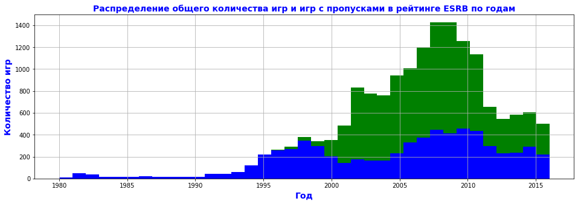

```python
rating_nan = players.loc[players['rating'] == 'absent']

ax = players['year_of_release'].plot(kind='hist', bins= 37, grid=True, color='green', figsize=(16,5))
ax = rating_nan['year_of_release'].plot(kind='hist', bins= 37, grid=True, color='blue', figsize=(16,5))
ax.set_xlabel('Год', fontsize=14, fontweight="bold", color='blue')
ax.set_ylabel('Количество игр', fontsize=14, fontweight="bold", color='blue')
ax.set_title('Распределение общего количества игр и игр с пропусками в рейтинге ESRB по годам',
             fontsize=14, fontweight="bold", color='blue')
None
```

*Выводы:*\ *Выяснено, что данные предоставлены за период с 1980 по 2016 год. Организация Entertainment Software Rating Board (ESRB) была основана в 1994 году и свою деятельность ведет только в США и Канаде. Игровые приставки набирали популярность и стали производиться и в других странах и регионах мира. И впоследствии в этих странах стали появляться свои рейтинговые организщации, но данные по ним в нашем датасете не присутствют. Поэтому значительное количество пропусков мы отмечаем в значениях оценок пользователей, критиков и рейтинга организации ESRB.*

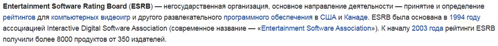

*В столбце оценка пользователей 'user_score' наблюдали значение 'tbd' (to be determined = будет определено) и мы их заменили на пропуски. В столбце рейтинга организации заменили пропуски на значение "absent".* https://ru.wikipedia.org/wiki/Entertainment_Software_Rating_Board#:~:text=Entertainment%20Software%20Rating%20Board%20

## Шаг 3. Проведём исследовательский анализ данных

3.1 Посмотрим сколько игр выпускалось в разные годы. Важны ли эти данные за все периоды.

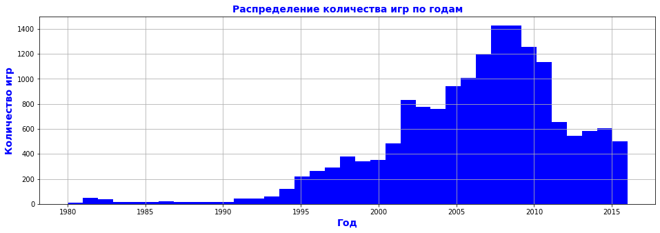

```python
ax = players['year_of_release'].plot(kind='hist', bins= 37, grid=True, color='blue', figsize=(16,5))
ax.set_xlabel('Год', fontsize=14, fontweight="bold", color='blue')
ax.set_ylabel('Количество игр', fontsize=14, fontweight="bold", color='blue')
ax.set_title('Распределение количества игр по годам', fontsize=14, fontweight="bold", color='blue')
None
```

*Проводимое нами исследование на поиск закономерностей не сможет отражать объективную картину в период отсутствия деятельности организации Entertainment Software Rating Board (ESRB). Данный график демонстрируеит, что активный рост продаж как раз начинается с 1995 года.*

3.2 Выясним существует ли связь между появлением возрастного рейтинга и количеством выпущенных игр.

*Посмотрим повлияло ли на количество появление новых игр рейтингов с ограничением по возрасту таких, как:*

*«M» («Mature») — «Для взрослых»:*  
Материалы игры не подходят для лиц младше 17 лет. Проекты с данным рейтингом могут содержать жестокое насилие, большое количество крови с расчленением, непристойные сексуальные сцены или грубую ненормативную лексику.

*«AO» («Adults Only 18+») — «Только для взрослых»:*  
Содержание игры только для взрослых старше 18 лет. Продукты из данной категории могут содержать длительные сцены жестокого насилия и/или очень откровенное сексуальное содержимое.

*«RP 17+» («Rating Pending») — «Рейтинг ожидается - примерно 17+»:*  
Продукт отправлен ESRB на оценку, но примерное содержание близко к рейтингу «M». Данная маркировка была введена с 2021 г. и распространяется на демо или презентационный вариант.

```python
players['rating'].unique()
```

```
array(['E', 'absent', 'M', 'T', 'E10+', 'K-A', 'AO', 'EC', 'RP'],
      dtype=object)
```

```python
players.pivot_table(index='year_of_release', columns='rating', values='name', aggfunc='count')
```

| rating year_of_release | AO | E | E10+ | EC | K-A | M | RP | T | absent |
| --- | --- | --- | --- | --- | --- | --- | --- | --- | --- |
| 1980 | NaN | NaN | NaN | NaN | NaN | NaN | NaN | NaN | 9.0 |
| 1981 | NaN | NaN | NaN | NaN | NaN | NaN | NaN | NaN | 46.0 |
| 1982 | NaN | NaN | NaN | NaN | NaN | NaN | NaN | NaN | 36.0 |
| 1983 | NaN | NaN | NaN | NaN | NaN | NaN | NaN | NaN | 17.0 |
| 1984 | NaN | NaN | NaN | NaN | NaN | NaN | NaN | NaN | 14.0 |
| 1985 | NaN | NaN | NaN | NaN | NaN | NaN | NaN | 1.0 | 13.0 |
| 1986 | NaN | NaN | NaN | NaN | NaN | NaN | NaN | NaN | 21.0 |
| 1987 | NaN | NaN | NaN | NaN | NaN | NaN | NaN | NaN | 16.0 |
| 1988 | NaN | NaN | 1.0 | NaN | NaN | NaN | NaN | NaN | 14.0 |
| 1989 | NaN | NaN | NaN | NaN | NaN | NaN | NaN | NaN | 17.0 |
| 1990 | NaN | NaN | NaN | NaN | NaN | NaN | NaN | NaN | 16.0 |
| 1991 | NaN | NaN | NaN | NaN | NaN | NaN | NaN | NaN | 41.0 |
| 1992 | NaN | NaN | NaN | NaN | NaN | 1.0 | NaN | 1.0 | 41.0 |
| 1993 | NaN | NaN | NaN | NaN | NaN | NaN | NaN | NaN | 60.0 |
| 1994 | NaN | NaN | NaN | NaN | NaN | NaN | NaN | 1.0 | 120.0 |
| 1995 | NaN | NaN | NaN | NaN | NaN | NaN | NaN | NaN | 219.0 |
| 1996 | NaN | 1.0 | NaN | NaN | 1.0 | 3.0 | NaN | 2.0 | 256.0 |
| 1997 | NaN | 6.0 | NaN | NaN | 2.0 | 2.0 | NaN | 9.0 | 270.0 |
| 1998 | NaN | 13.0 | NaN | NaN | NaN | 4.0 | NaN | 15.0 | 347.0 |
| 1999 | NaN | 20.0 | NaN | NaN | NaN | 5.0 | NaN | 17.0 | 296.0 |
| 2000 | NaN | 83.0 | NaN | NaN | NaN | 13.0 | NaN | 52.0 | 202.0 |
| 2001 | NaN | 205.0 | NaN | NaN | NaN | 27.0 | NaN | 107.0 | 143.0 |
| 2002 | NaN | 362.0 | NaN | NaN | NaN | 62.0 | NaN | 231.0 | 174.0 |
| 2003 | NaN | 289.0 | 3.0 | NaN | NaN | 83.0 | NaN | 238.0 | 162.0 |
| 2004 | NaN | 269.0 | 10.0 | NaN | NaN | 101.0 | NaN | 218.0 | 164.0 |
| 2005 | 1.0 | 246.0 | 102.0 | 2.0 | NaN | 135.0 | NaN | 220.0 | 233.0 |
| 2006 | NaN | 252.0 | 133.0 | NaN | NaN | 82.0 | NaN | 211.0 | 328.0 |
| 2007 | NaN | 352.0 | 164.0 | NaN | NaN | 85.0 | NaN | 220.0 | 376.0 |
| 2008 | NaN | 450.0 | 183.0 | NaN | NaN | 92.0 | NaN | 256.0 | 446.0 |
| 2009 | NaN | 435.0 | 194.0 | 1.0 | NaN | 122.0 | NaN | 259.0 | 415.0 |
| 2010 | NaN | 320.0 | 147.0 | 4.0 | NaN | 97.0 | NaN | 231.0 | 456.0 |
| 2011 | NaN | 223.0 | 150.0 | 1.0 | NaN | 124.0 | 1.0 | 204.0 | 433.0 |
| 2012 | NaN | 93.0 | 54.0 | NaN | NaN | 129.0 | NaN | 79.0 | 298.0 |
| 2013 | NaN | 83.0 | 67.0 | NaN | NaN | 104.0 | NaN | 62.0 | 228.0 |
| 2014 | NaN | 66.0 | 84.0 | NaN | NaN | 116.0 | NaN | 79.0 | 236.0 |
| 2015 | NaN | 87.0 | 51.0 | NaN | NaN | 71.0 | NaN | 106.0 | 291.0 |
| 2016 | NaN | 66.0 | 50.0 | NaN | NaN | 78.0 | NaN | 86.0 | 222.0 |

```python
players.loc[players['rating'] == 'AO']
```

|  | name | platform | year_of_release | genre | na_sales | eu_sales | jp_sales | other_sales | critic_score | user_score | rating | sum_sales |
| --- | --- | --- | --- | --- | --- | --- | --- | --- | --- | --- | --- | --- |
| 875 | Grand Theft Auto: San Andreas | XB | 2005 | Action | 1.26 | 0.61 | 0.0 | 0.09 | 93.0 | 8.6 | AO | 1.96 |

*Рейтинг игр «AO» («Adults Only 18+» — «Только для взрослых») был присвоен только 1 раз игре «Grand Theft Auto: San Andreas» на платформе Xbox (XB) в 2005 году. Рейтинг «RP 17+» («Rating Pending» — «Рейтинг ожидается - примерно 17+») так и не разу не был присвоен. Видимо все остальные возрастные ограничения возложили только на рейтинг «M» («Mature» — «Для взрослых»).*

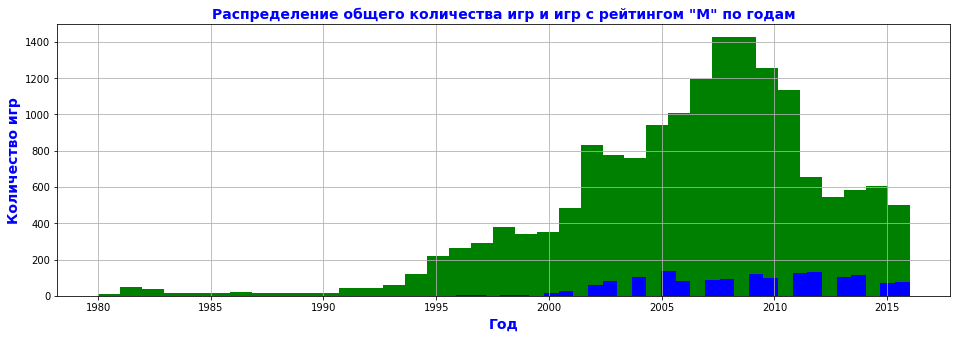

```python
rating_M = players.loc[players['rating'] == 'M']

ax = players['year_of_release'].plot(kind='hist', bins= 37, grid=True, color='green', figsize=(16,5))
ax = rating_M['year_of_release'].plot(kind='hist', bins= 37, grid=True, color='blue', figsize=(16,5))

ax.set_xlabel('Год', fontsize=14, fontweight="bold", color='blue')
ax.set_ylabel('Количество игр', fontsize=14, fontweight="bold", color='blue')
ax.set_title('Распределение общего количества игр и игр с рейтингом "M" по годам', fontsize=14, fontweight="bold", color='blue')

plt.show()
```

*Исследование показало, что незначительное количество игр с указанием возрастного рейтинга по отношению к общему количеству новых игр не могло повлиять на выпуск новых игр впоследствии. Связь между ними отсутствует.*

3.3 Посмотрим, как менялись продажи по платформам. Выберем платформы с наибольшими суммарными продажами и построим распределение по годам. Выясним за какой характерный срок появляются новые и исчезают старые платформы.

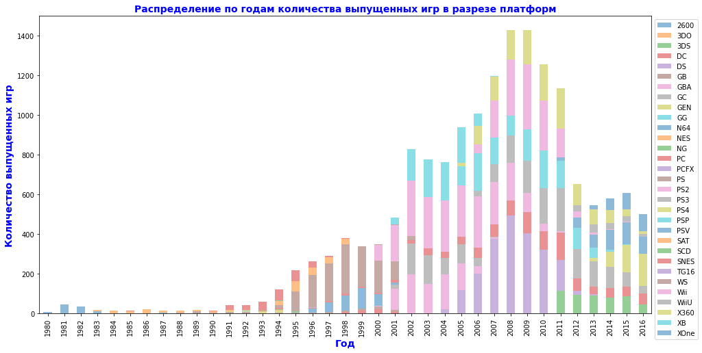

```python
fig, ax = plt.subplots()

players.pivot_table(index='platform',columns='year_of_release',values='name',
              aggfunc='count').T.plot(kind='bar',stacked=True, ax=ax, figsize=(16,8), alpha=0.5)

ax.legend(bbox_to_anchor=(1.0, 1.0))
ax.set_xlabel('Год', fontsize=14, fontweight="bold", color='blue')
ax.set_ylabel('Количество выпущенных игр', fontsize=14, fontweight="bold", color='blue')
ax.set_title('Распределение по годам количества выпущенных игр в разрезе платформ',
             fontsize=14, fontweight="bold", color='blue')
plt.show()
```

```python
players.groupby('platform').sum()[['sum_sales']].reset_index().sort_values(by='sum_sales', ascending=False).head()
```

|  | platform | sum_sales |
| --- | --- | --- |
| 16 | PS2 | 1233.56 |
| 28 | X360 | 961.24 |
| 17 | PS3 | 931.34 |
| 26 | Wii | 891.18 |
| 4 | DS | 802.78 |

*Исследование распределения платформ по годам показало:*

- максимальное количество игр выпускалось с 2002-го по 2011-й годы;
- выделяются 5 платформ с максимальным количеством игр - это платформы PS2 и PS3 (производитель Sony), DS и Wii (производитель Nintendo), X360 (производитель Microsoft);
- есть платформы, которые больше не выпускают игры и есть производители платформ активно присутствующие на рынке и на момент выгрузки данных.

*Для выявления закономерности успешности игр, что является целью нашего исследованиия, анализировать платформы, которые не выпускали игры продолжительное время, не целесообразно.*

3.4 Возьмем данные за соответствующий актуальный период. Актуальный период определим самостоятельно в результате исследования предыдущих вопросов. Основной фактор — эти данные помогут построить прогноз на 2017 год.

```python
players[['platform', 'sum_sales']].sort_values(by='sum_sales', ascending=False).head(10)
```

|  | platform | sum_sales |
| --- | --- | --- |
| 0 | Wii | 82.54 |
| 1 | NES | 40.24 |
| 2 | Wii | 35.52 |
| 3 | Wii | 32.77 |
| 4 | GB | 31.38 |
| 5 | GB | 30.26 |
| 6 | DS | 29.80 |
| 7 | Wii | 28.91 |
| 8 | Wii | 28.32 |
| 9 | NES | 28.31 |

```python
players.groupby('platform').sum()[['sum_sales']].reset_index().sort_values(by='sum_sales', ascending=False).head(10)
```

|  | platform | sum_sales |
| --- | --- | --- |
| 16 | PS2 | 1233.56 |
| 28 | X360 | 961.24 |
| 17 | PS3 | 931.34 |
| 26 | Wii | 891.18 |
| 4 | DS | 802.78 |
| 15 | PS | 727.58 |
| 18 | PS4 | 314.14 |
| 6 | GBA | 312.88 |
| 19 | PSP | 289.53 |
| 2 | 3DS | 257.81 |

*Возьмём для дальнейшего исследования первые 10 крупных платформ.*

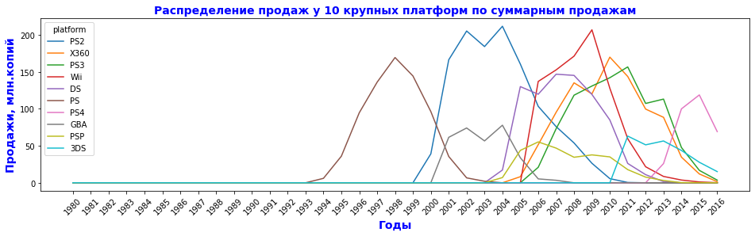

```python
top_sum_price = players.pivot_table(index = 'year_of_release',
    columns = 'platform',values = 'sum_sales', aggfunc = 'sum').fillna(0)

top_sum_price = top_sum_price[['PS2', 'X360','PS3','Wii', 'DS', 'PS', 'PS4', 'GBA', 'PSP', '3DS']]
ax = top_sum_price.plot(xticks=top_sum_price.index,figsize=(16,4))
plt.xticks(rotation = 45)
ylab = ax.set_ylabel('Продажи, млн.копий', fontsize=14, fontweight="bold", color='blue')
xlab = ax.set_xlabel('Годы', fontsize=14, fontweight="bold", color='blue')
plt.title('Распределение продаж у 10 крупных платформ по суммарным продажам', fontsize=14, fontweight="bold", color='blue')
plt.show()
```

*Проанализируем срединное время жизни игровой платформы.*

```python
temp = players.copy()
time_life = temp.pivot_table(index='platform', values='year_of_release', aggfunc=['min', 'max']).reset_index()
time_life['life'] = time_life['max'] - time_life['min'] + 1 # в срок жизни платформы, должны входить границы диапазона,
                                                            # поэтому +1

time_life['life'].median()
```

```
7.0
```

*Проанализируем срединное время жизни игровой платформы до 2012 года.*

```python
temp = players.query('year_of_release <= 2012').copy()
time_life = temp.pivot_table(index='platform', values='year_of_release', aggfunc=['min', 'max']).reset_index()
time_life['life'] = time_life['max'] - time_life['min'] + 1 # в срок жизни платформы, должны входить границы диапазона,
                                                            # поэтому +1
time_life['life'].median()
```

```
7.0
```

*Проанализируем срединное время жизни игровой платформы после 2012 года.*

```python
temp = players.query('year_of_release >= 2012').copy()
time_life = temp.pivot_table(index='platform', values='year_of_release', aggfunc=['min', 'max']).reset_index()
time_life['life'] = time_life['max'] - time_life['min'] + 1 # в срок жизни платформы, должны входить границы диапазона,
                                                            # поэтому +1
time_life['life'].median()
```

```
5.0
```

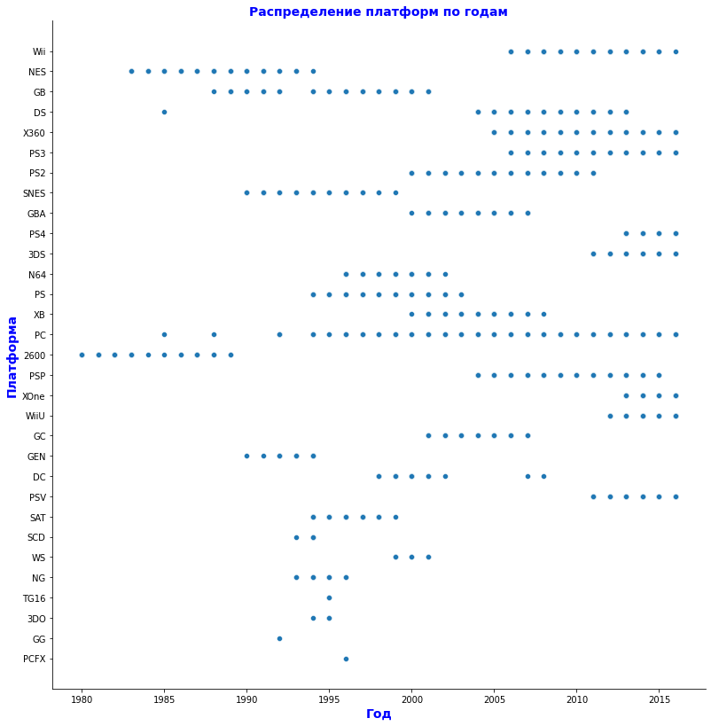

```python
sns.relplot(data = players, y = 'platform', x = 'year_of_release', height=11)
plt.title('Распределение платформ по годам', fontsize=14, fontweight="bold", color='blue')
plt.xlabel('Год', fontsize=14, fontweight="bold", color='blue')
plt.ylabel('Платформа', fontsize=14, fontweight="bold", color='blue')
plt.show()
None
```

*На графике отчетливо наблюдается общая картина - это цикличность подьема и спада продаж игровых платформ. Мы определили средний срок жизни платформы 7 лет. Но анализ за период после 2012 года показал, что время жизни уже 5 лет. Технологии динамично развиваются и на смену старым приходят новые платформы. Если новая платформа в течении 3-5 лет увеличивает объем своей выручки, то можно еще 2 года наблюдать её рост до пика популярности. Примерно в этот же период через 5 лет с момента выхода на рынок платформы, до начала максимального объема продаж, на рынке появляются новые платформы и начинают их вытеснять. Выяснено, что через 3-5 лет с момента повления популярной платформы, на рынке появляются новые. И оставшиеся 5-7 лет начинается спад продаж старых платформ.*

3.5 Определим какой период данных можно не учитывать в нашем исследовании в дальнейшем.

*Для решения поставленной задачи прогноза продаж на 2017 год, мы должны воспользоваться полученным нами ранее выводом. Таким образом мы должны проанализировать предыдущие 5 лет с целью поиска растущих за этот период перспективных платформ. Будем изучать период с 2012 по 2016 год включительно.*

3.6 Выясним какие платформы лидируют по продажам, растут или падают. Выберем несколько потенциально прибыльных платформ.

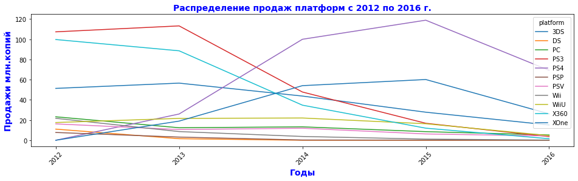

```python
players_2012 = players.query('year_of_release >= 2012')
per_price = players_2012.query('year_of_release >= 2012').pivot_table(index = 'year_of_release',
        columns = 'platform', values = 'sum_sales', aggfunc = 'sum').fillna(0)

ax = per_price.plot(xticks=per_price.index, figsize=(16,4))
plt.xticks(rotation = 45)
ylab = ax.set_ylabel('Продажи млн.копий', fontsize=14, fontweight="bold", color='blue')
xlab = ax.set_xlabel('Годы', fontsize=14, fontweight="bold", color='blue')
plt.title('Распределение продаж платформ с 2012 по 2016 г.', fontsize=14, fontweight="bold", color='blue')
plt.show()
```

*Исследование показало, что самыми популярными в 2017 году будут платформы Sony PlayStation 4 (PS4) и Xbox One от Microsoft (XOne). Какое-то время будут актуальны игры для платформ Nintendo 3DS (3DS), Wii U (Wii), Xbox 360 (X360) и PlayStation 3 (PS3).*

*Выяснили, что перспективными платформами являются PS4, PS3, XOne, X360, WiiU и 3DS, а актуальный период исследования - 5 лет, т.е. 2012-2016 годы. Проанализируем детальней эти платформы.*

3.7 Построим график «ящик с усами» по глобальным продажам игр в разбивке по платформам. Опишем результат.

```python
players_2012.head(10)
```

|  | name | platform | year_of_release | genre | na_sales | eu_sales | jp_sales | other_sales | critic_score | user_score | rating | sum_sales |
| --- | --- | --- | --- | --- | --- | --- | --- | --- | --- | --- | --- | --- |
| 16 | Grand Theft Auto V | PS3 | 2013 | Action | 7.02 | 9.09 | 0.98 | 3.96 | 97.0 | 8.2 | M | 21.05 |
| 23 | Grand Theft Auto V | X360 | 2013 | Action | 9.66 | 5.14 | 0.06 | 1.41 | 97.0 | 8.1 | M | 16.27 |
| 31 | Call of Duty: Black Ops 3 | PS4 | 2015 | Shooter | 6.03 | 5.86 | 0.36 | 2.38 | NaN | NaN | absent | 14.63 |
| 33 | Pokemon X/Pokemon Y | 3DS | 2013 | Role-Playing | 5.28 | 4.19 | 4.35 | 0.78 | NaN | NaN | absent | 14.60 |
| 34 | Call of Duty: Black Ops II | PS3 | 2012 | Shooter | 4.99 | 5.73 | 0.65 | 2.42 | 83.0 | 5.3 | M | 13.79 |
| 35 | Call of Duty: Black Ops II | X360 | 2012 | Shooter | 8.25 | 4.24 | 0.07 | 1.12 | 83.0 | 4.8 | M | 13.68 |
| 42 | Grand Theft Auto V | PS4 | 2014 | Action | 3.96 | 6.31 | 0.38 | 1.97 | 97.0 | 8.3 | M | 12.62 |
| 47 | Pokemon Omega Ruby/Pokemon Alpha Sapphire | 3DS | 2014 | Role-Playing | 4.35 | 3.49 | 3.10 | 0.74 | NaN | NaN | absent | 11.68 |
| 60 | Call of Duty: Ghosts | X360 | 2013 | Shooter | 6.73 | 2.56 | 0.04 | 0.91 | 73.0 | 2.6 | M | 10.24 |
| 62 | New Super Mario Bros. 2 | 3DS | 2012 | Platform | 3.66 | 3.14 | 2.47 | 0.63 | 78.0 | 7.2 | E | 9.90 |

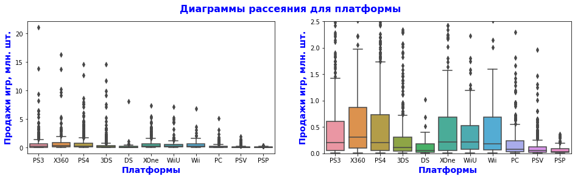

```python
fig, axes = plt.subplots(1, 2, figsize=(16, 4))

sns.boxplot(x='platform', y='sum_sales', data=players_2012, ax=axes[0])

axes[0].set_ylabel('Продажи игр, млн. шт.', fontsize=14, fontweight="bold", color='blue')
axes[0].set_xlabel('Платформы', fontsize=14, fontweight="bold", color='blue')


sns.boxplot(x='platform', y='sum_sales', data=players_2012, ax=axes[1])
axes[1].set_ylim(0, 2.5)
axes[1].set_ylabel('Продажи игр, млн. шт.', fontsize=14, fontweight="bold", color='blue')
axes[1].set_xlabel('Платформы', fontsize=14, fontweight="bold", color='blue')

plt.suptitle(f'Диаграммы рассеяния для платформы', fontsize=16, fontweight="bold", color='blue')
plt.show()
```

3.8 Посмотрим, как влияют на продажи внутри одной популярной платформы отзывы пользователей и критиков. Построим диаграмму рассеяния и посчитаем корреляцию между отзывами и продажами. Сформулируем выводы. Опишем результат.

```python
players_2012.groupby('platform')[['user_score',
                                  'critic_score']].agg('mean').round(2).sort_values(by='critic_score', ascending=False)
```

| platform | user_score | critic_score |
| --- | --- | --- |
| DS | 7.00 | 80.00 |
| Wii | 6.08 | 76.20 |
| PC | 6.43 | 75.84 |
| PSP | 5.95 | 74.00 |
| XOne | 6.52 | 73.33 |
| PS4 | 6.75 | 72.09 |
| PS3 | 6.53 | 71.57 |
| PSV | 7.41 | 71.33 |
| X360 | 6.22 | 70.87 |
| WiiU | 6.90 | 70.73 |
| 3DS | 7.03 | 69.82 |

*Построим диаграмму рассеяния и посчитаем корреляцию между отзывами пользователей, критиков и продажами для платформы PS3.*

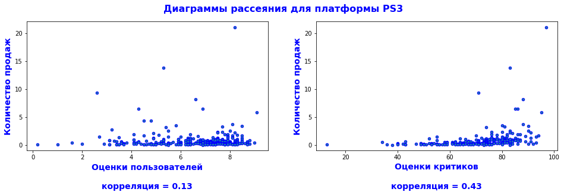

```python
platform_list = ['PS3']

for platform in platform_list:
    f, ax = plt.subplots(1,2)

    players_corr = players_2012.query('platform == @platform')

    players_corr.plot(kind='scatter', x='user_score', y='sum_sales', ec='blue', figsize=(16,4), ax=ax[0])
    corr1 = round(players.query('platform == @platform')['sum_sales'].
              corr(players.query('platform == @platform')['user_score']),2)

    ax[0].set_xlabel(f'Оценки пользователей\n\nкорреляция = {corr1}', fontsize=14, fontweight="bold", color='blue')
    ax[0].set_ylabel('Количество продаж', fontsize=14, fontweight="bold", color='blue')

    players_corr.plot(kind='scatter', x='critic_score', y='sum_sales', ec='blue', figsize=(16,4), ax=ax[1])
    corr2 = round(players.query('platform == @platform')['sum_sales'].
              corr(players.query('platform == @platform')['critic_score']),2)

    ax[1].set_xlabel(f'Оценки критиков\n\nкорреляция = {corr2}', fontsize=14, fontweight="bold", color='blue')
    ax[1].set_ylabel('Количество продаж', fontsize=14, fontweight="bold", color='blue')

    plt.suptitle(f'Диаграммы рассеяния для платформы {platform}', fontsize=16, fontweight="bold", color='blue')
    plt.show()
```

*Наблюдаем очень слабую связь между отзывами пользователей платформы PS3 и слабую связь отзывов критиков этой платформы с объемами продаж. Не наблюдается явного влияния на продажи платформы PS3 отзывов пользователей и критиков. Но оценки критиков влияют чуть больше.*

3.9 Соотнесём выводы с продажами игр на других платформах. Опишем результат.

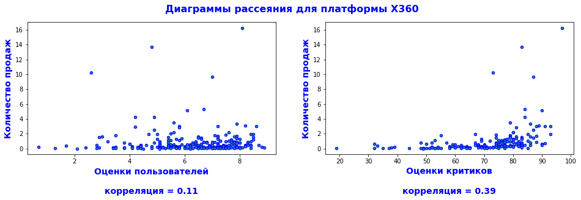

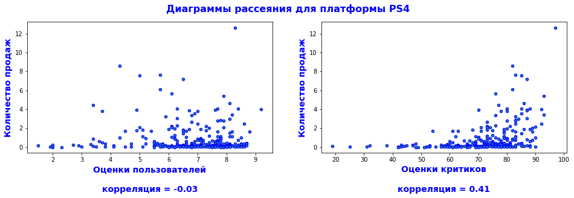

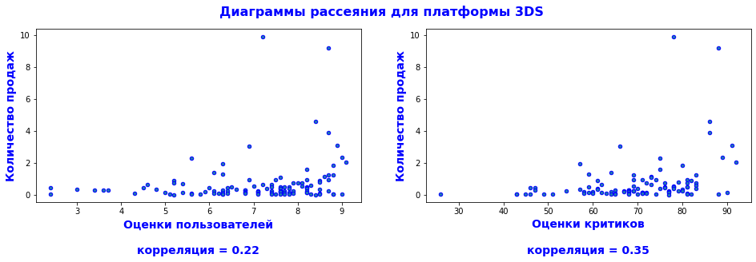

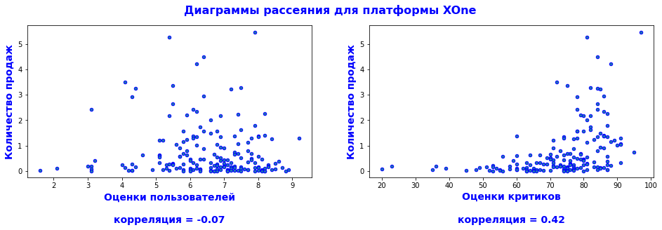

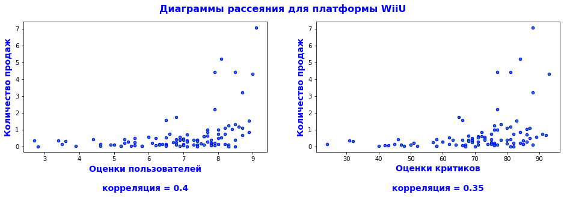

```python
platform_list = ['X360', 'PS4', '3DS', 'XOne', 'WiiU']

for platform in platform_list:
    f, ax = plt.subplots(1,2)

    players_corr = players_2012.query('platform == @platform')

    players_corr.plot(kind='scatter', x='user_score', y='sum_sales', ec='blue', figsize=(16,4), ax=ax[0])
    corr1 = round(players.query('platform == @platform')['sum_sales'].
              corr(players.query('platform == @platform')['user_score']),2)

    ax[0].set_xlabel(f'Оценки пользователей\n\nкорреляция = {corr1}', fontsize=14, fontweight="bold", color='blue')
    ax[0].set_ylabel('Количество продаж', fontsize=14, fontweight="bold", color='blue')

    players_corr.plot(kind='scatter', x='critic_score', y='sum_sales', ec='blue', figsize=(16,4), ax=ax[1])
    corr2 = round(players.query('platform == @platform')['sum_sales'].
              corr(players.query('platform == @platform')['critic_score']),2)

    ax[1].set_xlabel(f'Оценки критиков\n\nкорреляция = {corr2}', fontsize=14, fontweight="bold", color='blue')
    ax[1].set_ylabel('Количество продаж', fontsize=14, fontweight="bold", color='blue')

    plt.suptitle(f'Диаграммы рассеяния для платформы {platform}', fontsize=16, fontweight="bold", color='blue')
    plt.show()
```